# Machine Learning: Predict exercise pattern

Satya

November 10, 2016

# Machine Learning Project: Excercise Pattern prediction

### 1. Executive Summary

Excercise data collected from various sources such as Jawbone up, Nike and Fitbit and the collected data is about personal activity from all these devices in an inexpensive manner. Predicgtion analysis is related to improve health and find patterns in their behavior.

In this project, goal is to use to pridict the manner in which 6 participants performed excercised in the data. This is the “classe” variable in the training data set. The machine learning applied 20 test cases availble in test data for prediction

## 2 Background

Data was collected using various sources from personal activities. Different types of devices are part of quantified movements and data used to predict to improve the health by trying to find patterns in bevaiour. In this project, your goal will be to use data from accelerometers on the belt, forearm, arm, and dumbell of 6 participants.

## 3. Data Loading and Exploratory Analysis

### Data source:

### Training Data

https://d396qusza40orc.cloudfront.net/predmachlearn/pml-training.csv

### Test Data

https://d396qusza40orc.cloudfront.net/predmachlearn/pml-testing.csv

### Techinical Analysis

```r
library(knitr)
library(caret)
library(rpart)
```

```r
library(rpart.plot)
library(rattle)
library(randomForest)
library(corrplot)
library(gbm)
set.seed(301)
```

# c. Data Loading and Cleaning

Dataset loaded from the URL provided from the above. The training dataset partitioned into 2 to create a training set with 70% of the dataset and for test dataset with 30% dataset for validations.

```r
TrainUrl <- "https://d396qusza40orc.cloudfront.net/predmachlearn/pml-training.csv"
TestUrl  <- "https://d396qusza40orc.cloudfront.net/predmachlearn/pml-testing.csv"
TrainFile<-"pml-traininig.csv"
TestFile<-"pml-testing.csv"

# download the datasets
if(!file.exists(TrainFile))
{
    download.file(TrainUrl,destfile = TrainFile)
}
training <- read.csv(TrainFile)
if(!file.exists(TestFile))
{
    download.file(TestUrl,destfile = TestFile)
}
testing  <- read.csv(TestFile)

# create a partition using caret with the training dataset on 70,30 ratio
inTrain  <- createDataPartition(training$classe, p=0.7, list=FALSE)

TrainSet <- training[inTrain, ]

TestSet  <- training[-inTrain, ]
dim(TrainSet)
```

```
## [1] 13737   160
```

```r
dim(TestSet)
```

```
## [1] 5885  160
```

Training set has 160 variable. One of the dependent variable as used for this stufy of this project. Dataset requires to clean NA values. The Near Zero variance (NZV) and the ID variables as well.

```r
NZV <- nearZeroVar(TrainSet)
TrainSet <- TrainSet[, -NZV]
TestSet  <- TestSet[, -NZV]
dim(TestSet)
```

```
## [1] 5885  106
```

```r
dim(TrainSet)
```

```
## [1] 13737   106
```

Remove variables that are mostly NA

```r
AllNA    <- sapply(TrainSet, function(x) mean(is.na(x))) > 0.95
TrainSet <- TrainSet[, AllNA==FALSE]
TestSet  <- TestSet[, AllNA==FALSE]
dim(TestSet)
```

```
## [1] 5885   59
```

```r
dim(TrainSet)
```

```
## [1] 13737    59
```

```r
TrainSet <- TrainSet[, -(1:5)]
TestSet  <- TestSet[, -(1:5)]
dim(TrainSet)
```

```
## [1] 13737    54
```

After cleaning, we can see that the number of vairables for the analysis are now only 53.

# d.Coorection Analysis

A correlation among variables is analysed before proceeding to the modeling procedures.

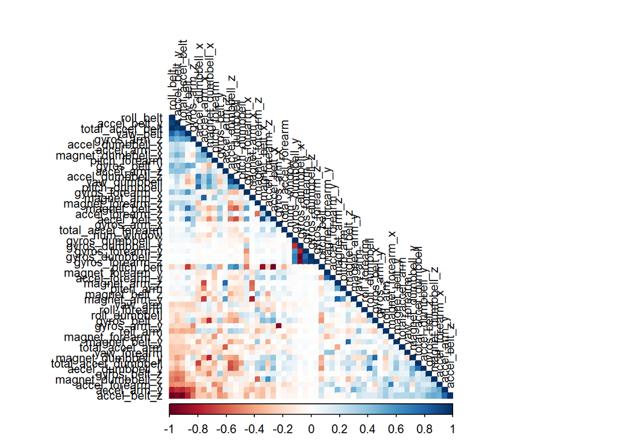

```r
corMatrix <- cor(TrainSet[, -54])
corrplot(corMatrix, order = "FPC", method = "color", type = "lower",
         tl.cex = 0.8, tl.col = rgb(0, 0, 0))
```

More correlated variables showed in dark colors in the graph. To make an even more compact analysis, a PCA (Principal Components Analysis) could be performed as pre-processing step to the datasets. Nevertheless, as the correlations are quite few, this step will not be applied for this assignment.

# 4. Prediction Model Building

Three popular methods applied to model the regressions using the Train dataset. The best one (with higher accuracy when applied to the Test dataset) will be used for the quiz predictions. The methods are: Random Forests, Decision Tree and Generalized Boosted Model, as described below. A Confusion Matrix is plotted at the end of each analysis to better visualize the accuracy of the models.

## a. Random Forests

```r
set.seed(301)
controlRF <- trainControl(method="cv", number=3, verboseIter=FALSE)
modFitRandForest <- train(classe ~ ., data=TrainSet, method="rf",
                          trControl=controlRF)
modFitRandForest$finalModel
```

```
##
## Call:
##  randomForest(x = x, y = y, mtry = param$mtry)
##                Type of random forest: classification
##                      Number of trees: 500
## No. of variables tried at each split: 27
##
##         OOB estimate of  error rate: 0.25%
## Confusion matrix:
##      A    B    C    D    E  class.error
## A 3905    0    0    0    1 0.0002560164
## B    4 2649    4    1    0 0.0033860045
## C    0    8 2388    0    0 0.0033388982
## D    0    0    9 2242    1 0.0044404973
## E    0    0    0    7 2518 0.0027722772
```

```r
predictRandForest <- predict(modFitRandForest, newdata=TestSet)
confMatRandForest <- confusionMatrix(predictRandForest, TestSet$classe)
confMatRandForest
```

```
## $positive
## NULL
##
## $table
##           Reference
## Prediction    A    B    C    D    E
##          A 1673   10    0    0    0
##          B    1 1128    6    0    0
##          C    0    1 1020    1    0
##          D    0    0    0  963    0
##          E    0    0    0    0 1082
##
## $overall
##       Accuracy          Kappa  AccuracyLower  AccuracyUpper   AccuracyNull
##      0.9967715      0.9959155      0.9949628      0.9980551      0.2844520
## AccuracyPValue  McnemarPValue
##      0.0000000            NaN
##
## $byClass
##          Sensitivity Specificity Pos Pred Value Neg Pred Value Precision
## Class: A   0.9994026   0.9976253      0.9940582      0.9997620 0.9940582
## Class: B   0.9903424   0.9985251      0.9938326      0.9976842 0.9938326
## Class: C   0.9941520   0.9995884      0.9980431      0.9987662 0.9980431
## Class: D   0.9989627   1.0000000      1.0000000      0.9997968 1.0000000
## Class: E   1.0000000   1.0000000      1.0000000      1.0000000 1.0000000
##             Recall        F1 Prevalence Detection Rate
## Class: A 0.9994026 0.9967233  0.2844520      0.2842821
## Class: B 0.9903424 0.9920844  0.1935429      0.1916737
## Class: C 0.9941520 0.9960938  0.1743415      0.1733220
## Class: D 0.9989627 0.9994811  0.1638063      0.1636364
## Class: E 1.0000000 1.0000000  0.1838573      0.1838573
##          Detection Prevalence Balanced Accuracy
## Class: A            0.2859813         0.9985139
## Class: B            0.1928632         0.9944337
## Class: C            0.1736619         0.9968702
## Class: D            0.1636364         0.9994813
## Class: E            0.1838573         1.0000000
##
## $mode
## [1] "sens_spec"
##
## $dots
## list()
##
## attr(,"class")
## [1] "confusionMatrix"
```

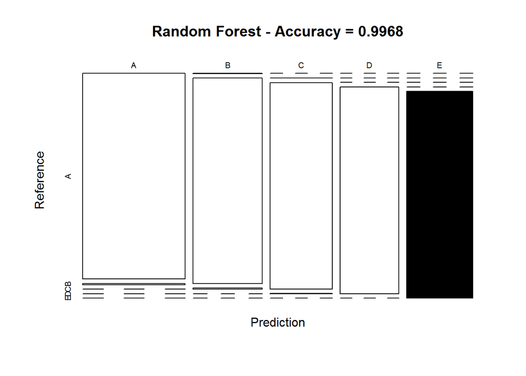

```r
plot(confMatRandForest$table, col = confMatRandForest$byClass,
     main = paste("Random Forest - Accuracy =",
                  round(confMatRandForest$overall['Accuracy'], 4)))
```

#b. Decision Tree

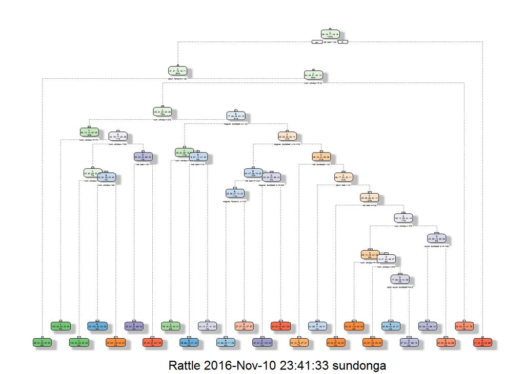

```r
set.seed(301)
modFitDecTree <- rpart(classe ~ ., data=TrainSet, method="class")
fancyRpartPlot(modFitDecTree)
```

```r
predictDecTree <- predict(modFitDecTree, newdata=TestSet, type="class")
confMatDecTree <- confusionMatrix(predictDecTree, TestSet$classe)
confMatDecTree
```

```
## $positive
## NULL
##
## $table
##           Reference
## Prediction    A    B    C    D    E
##          A 1441  107    2   15    5
##          B  156  880   73   80   56
##          C    0   48  848   29    0
##          D   64   58   98  761   72
##          E   13   46    5   79  949
##
## $overall
##       Accuracy          Kappa  AccuracyLower  AccuracyUpper   AccuracyNull
##   8.290569e-01   7.842555e-01   8.191913e-01   8.385952e-01   2.844520e-01
## AccuracyPValue  McnemarPValue
##   0.000000e+00   1.688986e-16
##
## $byClass
##          Sensitivity Specificity Pos Pred Value Neg Pred Value Precision
## Class: A   0.8608124   0.9693659      0.9178344      0.9460023 0.9178344
## Class: B   0.7726076   0.9230931      0.7068273      0.9441810 0.7068273
## Class: C   0.8265107   0.9841531      0.9167568      0.9641129 0.9167568
## Class: D   0.7894191   0.9406625      0.7226971      0.9579884 0.7226971
## Class: E   0.8770795   0.9702269      0.8690476      0.9722512 0.8690476
##             Recall        F1 Prevalence Detection Rate
## Class: A 0.8608124 0.8884094  0.2844520      0.2448598
## Class: B 0.7726076 0.7382550  0.1935429      0.1495327
## Class: C 0.8265107 0.8692978  0.1743415      0.1440952
## Class: D 0.7894191 0.7545860  0.1638063      0.1293118
## Class: E 0.8770795 0.8730451  0.1838573      0.1612574
##          Detection Prevalence Balanced Accuracy
## Class: A            0.2667799         0.9150892
## Class: B            0.2115548         0.8478503
## Class: C            0.1571793         0.9053319
## Class: D            0.1789295         0.8650408
## Class: E            0.1855565         0.9236532
##
## $mode
## [1] "sens_spec"
##
## $dots
## list()
##
## attr(,"class")
## [1] "confusionMatrix"
```

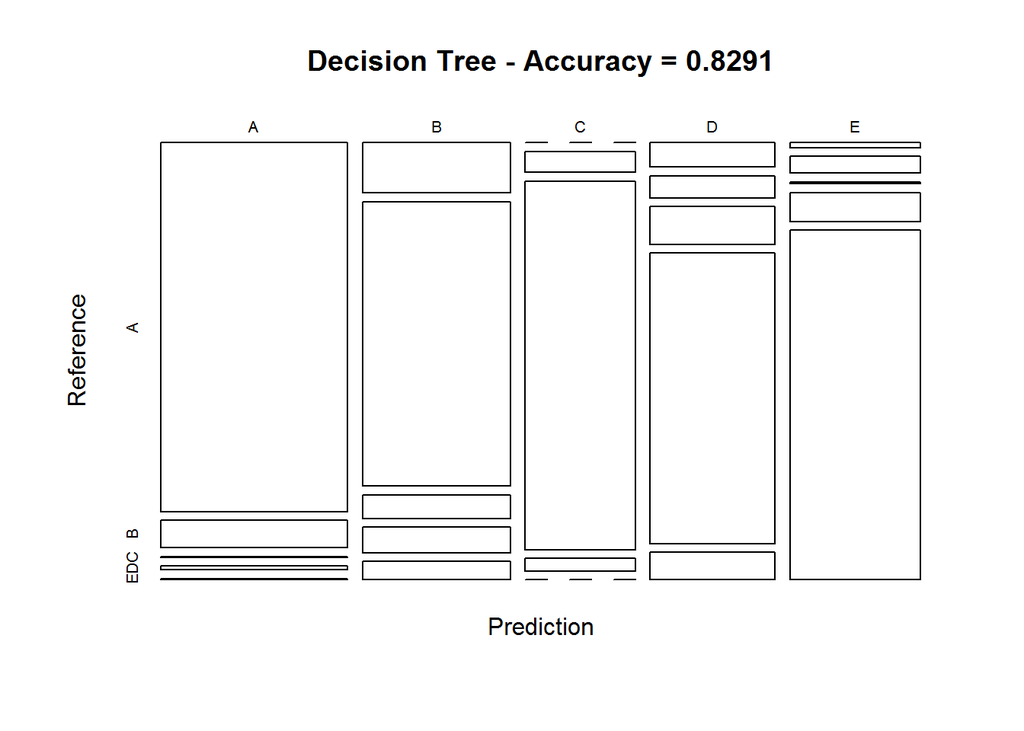

```r
plot(confMatDecTree$table, col = confMatDecTree$byClass,
     main = paste("Decision Tree - Accuracy =",
                  round(confMatDecTree$overall['Accuracy'], 4)))
```

#c. Generalized Boosted Model (GBM)

```r
set.seed(301)
controlGBM <- trainControl(method = "repeatedcv", number = 5, repeats = 1)
modFitGBM  <- train(classe ~ ., data=TrainSet, method = "gbm",
                    trControl = controlGBM, verbose = FALSE)
modFitGBM$finalModel
```

```
## A gradient boosted model with multinomial loss function.
## 150 iterations were performed.
## There were 53 predictors of which 45 had non-zero influence.
```

```r
predictGBM <- predict(modFitGBM, newdata=TestSet)
confMatGBM <- confusionMatrix(predictGBM, TestSet$classe)
confMatGBM
```

```
## $positive
## NULL
##
## $table
##           Reference
## Prediction    A    B    C    D    E
##          A 1669   14    0    0    0
##          B    1 1112    9    4    6
##          C    0    8 1015   12    1
##          D    4    5    2  948    9
##          E    0    0    0    0 1066
##
## $overall
##       Accuracy          Kappa  AccuracyLower  AccuracyUpper   AccuracyNull
##      0.9872557      0.9838779      0.9840508      0.9899630      0.2844520
## AccuracyPValue  McnemarPValue
##      0.0000000            NaN
##
## $byClass
##          Sensitivity Specificity Pos Pred Value Neg Pred Value Precision
## Class: A   0.9970131   0.9966754      0.9916815      0.9988101 0.9916815
## Class: B   0.9762950   0.9957859      0.9823322      0.9943194 0.9823322
## Class: C   0.9892788   0.9956781      0.9797297      0.9977315 0.9797297
## Class: D   0.9834025   0.9959358      0.9793388      0.9967460 0.9793388
## Class: E   0.9852126   1.0000000      1.0000000      0.9966798 1.0000000
##             Recall        F1 Prevalence Detection Rate
## Class: A 0.9970131 0.9943402  0.2844520      0.2836024
## Class: B 0.9762950 0.9793043  0.1935429      0.1889550
## Class: C 0.9892788 0.9844811  0.1743415      0.1724724
## Class: D 0.9834025 0.9813665  0.1638063      0.1610875
## Class: E 0.9852126 0.9925512  0.1838573      0.1811385
##          Detection Prevalence Balanced Accuracy
## Class: A            0.2859813         0.9968443
## Class: B            0.1923534         0.9860405
## Class: C            0.1760408         0.9924784
## Class: D            0.1644860         0.9896691
## Class: E            0.1811385         0.9926063
##
## $mode
## [1] "sens_spec"
##
## $dots
## list()
##
## attr(,"class")
## [1] "confusionMatrix"
```

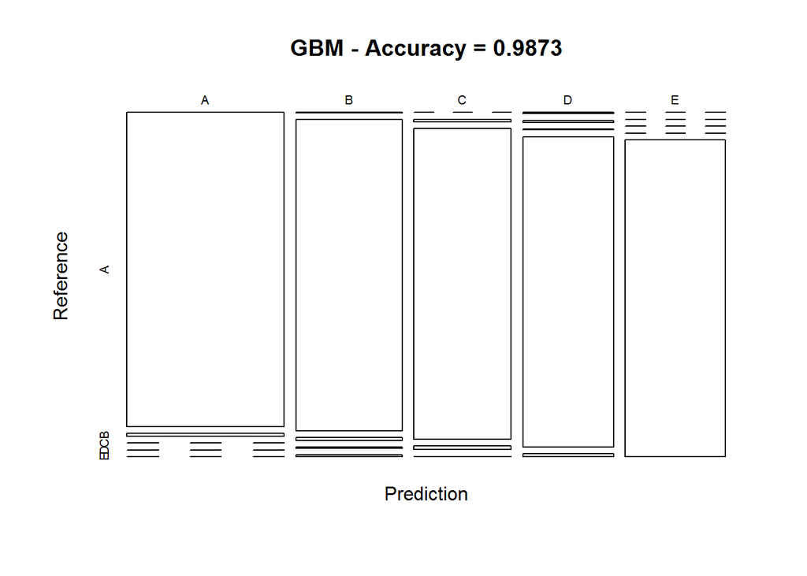

```r
plot(confMatGBM$table, col = confMatGBM$byClass,
     main = paste("GBM - Accuracy =", round(confMatGBM$overall['Accuracy'], 4)))
```

# 5. Applying the selected Model to the Test Data

```r
predictTEST <- predict(modFitRandForest, newdata=testing)
predictTEST
```

```
##  [1] B A B A A E D B A A B C B A E E A B B B
## Levels: A B C D E
```